# PA1_template

Jamie DeCoster

Saturday, October 18, 2014

## Loading and preprocessing the data

```r
cat("\014")
```

```r
setwd("C:/Users/Jamie/Dropbox/Coursera/2014-10-08 Reproducible Research/Assignment 1")
#setwd("C:/Users/jd4nb/Dropbox/Coursera/2014-10-08 Reproducible Research/Assignment 1")

library(reshape)

data <- read.csv("activity.csv", header = TRUE)
data <- data[order(data$date,data$interval),]
md <- melt(data, id = c("date", "interval"))
dataMatrix <- cast(md, date~interval)
```

## What is mean total number of steps taken per day?

1. Below is a histogram of the number of steps taken during each 5-minute period.

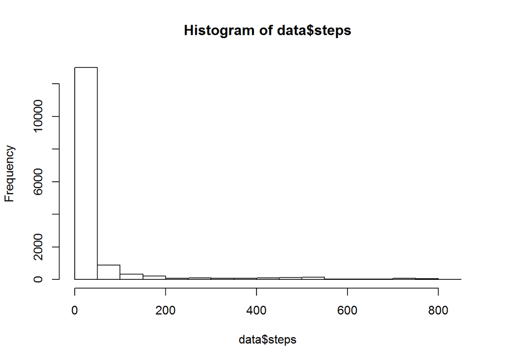

```r
hist(data$steps)
```

2. This distribution has a mean of 37.3826 and a median of 0.

```r
mean(data$steps, na.rm = TRUE)
```

```
## [1] 37.38
```

```r
median(data$steps, na.rm = TRUE)
```

```
## [1] 0
```

## What is the average daily activity pattern?

1. Below is a plot of the average number of steps for each of the time periods, averaging over day.

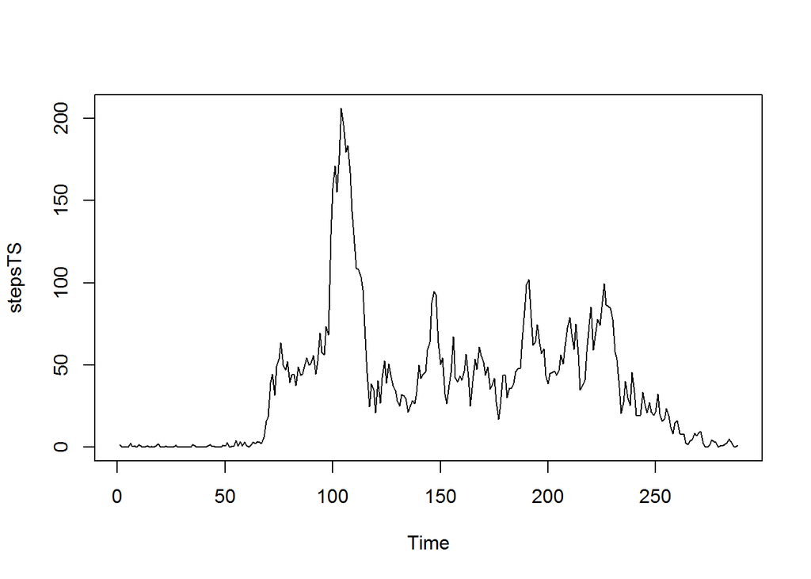

```r
stepsTS <- ts(data = apply(dataMatrix, 2, function(x)
          mean(x, na.rm=TRUE)))
plot.ts(stepsTS)
```

2. The five-minute interval with the maximum number of steps is 835. The mean number of steps during this interval is 206.1698.

```r
names(stepsTS)[which.max(stepsTS)]
```

```
## [1] "835"
```

```r
stepsTS[which.max(stepsTS)]
```

```
##   835
## 206.2
```

## Imputing missing values

1. Below are the counts of missing values for the variables in the data set.

```r
sapply(data, function(x) sum(is.na(x)))
```

```
##    steps     date interval
##     2304        0        0
```

From this we can see that the total number of missing values is 2304.

2. I would choose to replace missing values with the mean value for the corresponding time period.
3. The following code creates a data set “dataImputed” that replaces missing values with the mean value for the corresponding time period.

```r
# stepsTS contains the means by interval
# Can use this as the basis for the imputation
dataImputed <- data
for (t in 1:length(dataImputed$steps)) {
  if (is.na(dataImputed$steps[t])) {
    dataImputed$steps[t] <- stepsTS[as.character(dataImputed$interval[t])]
  }
}
```

4. Below is a histogram of the number of steps taken during each 5-minute period based on the imputed data.

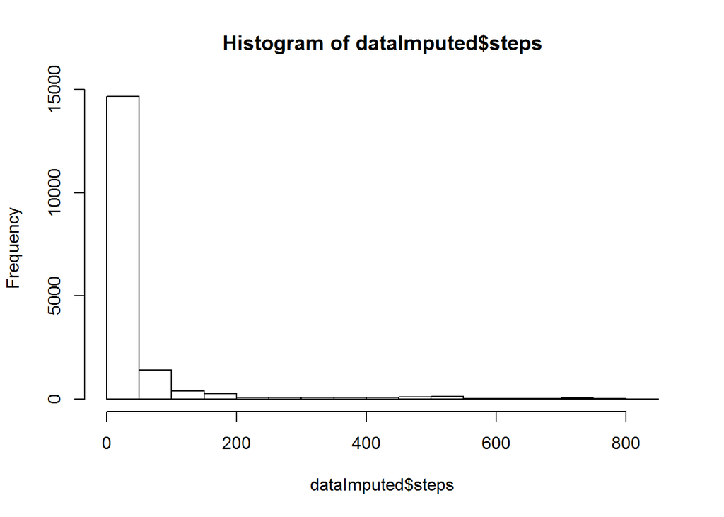

```r
hist(dataImputed$steps)
```

This distribution has a mean of 37.3826 and a median of 0.

```r
mean(dataImputed$steps)
```

```
## [1] 37.38
```

```r
median(dataImputed$steps)
```

```
## [1] 0
```

These numbers came out exactly the same. This is because using the mean of the missing values as a substution is the same thing as taking the mean of the non-missing values. A different imputation method would produce different results.

## Are there differences in activity patterns between weekdays and weekends?

1. The following code adds a new variable called “dayType” to the dataImputed data set, where the value is either “weekday” or “weekend” depending on the nature of the day.

```r
# Restructuring the imputed data so it will fit a time series
dataImputed <- dataImputed[order(data$date,data$interval),]
mdImputed <- melt(dataImputed, id = c("date", "interval"))
dataMatrixImputed <- cast(mdImputed, date~interval)

# Adding dayType variable
dayName <- lapply(as.Date(dataMatrixImputed$date), weekdays)
dayType <- vector()
for (t in 1:length(dayName)) {
  if (dayName[t] == "Saturday" | dayName[t] == "Sunday") {
    dayType[t] = "weekend"
  } else {
    dayType[t] = "weekday"
  }
}
dataMatrixImputed <- data.frame(dataMatrixImputed, dayType)
```

2. Below is a pair of plots showing how the time series for weekdays differs from the time series for weekends.

```r
dWeekday <- dataMatrixImputed[which(dataMatrixImputed$dayType == "weekday"),!names(dataMatrixImputed) == "dayType"]
dWeekend <- dataMatrixImputed[which(dataMatrixImputed$dayType == "weekend"),!names(dataMatrixImputed) == "dayType"]

par(mfrow=c(1,2))
stepsTSweekday <- ts(data = apply(dWeekday, 2, function(x)
          mean(as.numeric(x), na.rm=TRUE)))
```

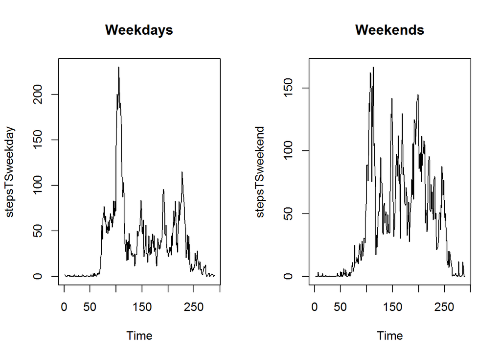

```r
plot.ts(stepsTSweekday,
        main = "Weekdays")
stepsTSweekend <- ts(data = apply(dWeekend, 2, function(x)
          mean(as.numeric(x), na.rm=TRUE)))
plot.ts(stepsTSweekend,
        main = "Weekends")
```